# COMP2200: Week 4

Fitting Models to Data

A/Prof Benjamin Pope

School of Mathematical and Physical Sciences

2025-03-17

Welcome!

### In these lectures

#### Week 4

- Lines of Best Fit
  - recap of RANSAC, Theil-Sen
  - ordinary least squares fits
  - multivariate ordinary least squares
  - fitting higher order models by least squares
  - least squares as maximum likelihood with Gaussian errors
- Classification
  - Bernoulli (coin-flip) distribution
  - log-odds and logistic regression

### Fitting a Line to Data

The most important thing in your whole job will be *learning* from data: finding a mathematical representation that explains current data and predicts new data.

This can be as simple as *fitting a line*.

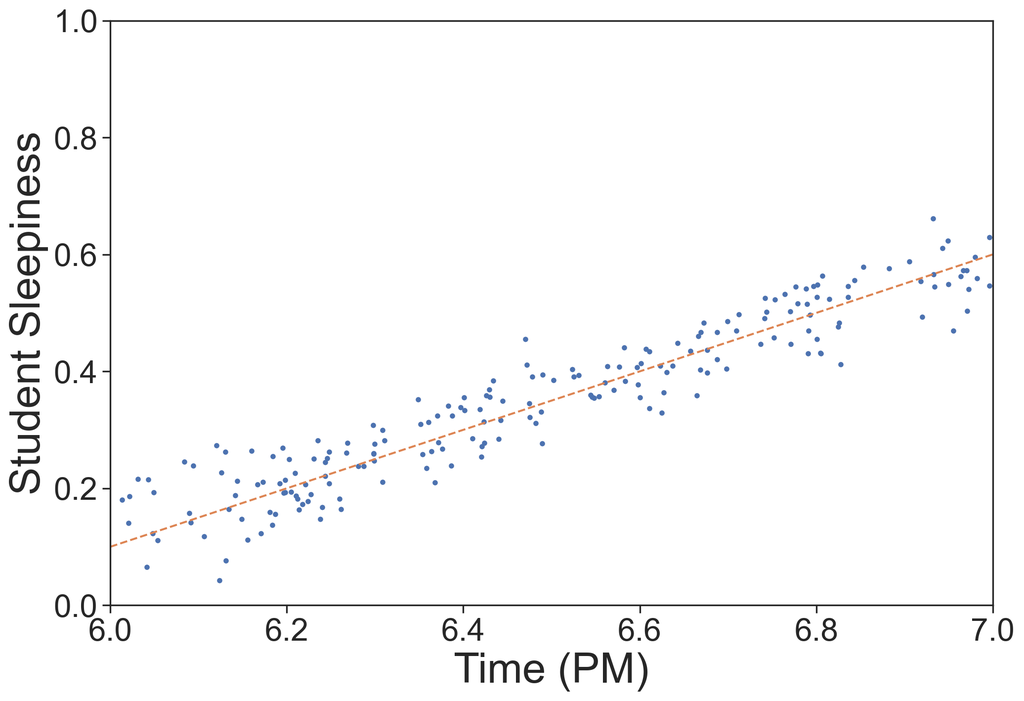

### An example dataset: Fish Market

We have a dataset with some wonderfully linear trends in it, that people often use for ML teaching: the [“fish market” dataset from Kaggle](https://www.kaggle.com/datasets/vipullrathod/fish-market/data). These have 3D measurements of fish of different species, including multiple definitions of length that should be *very* linear.

You can download these automatically:

```python
import kagglehub

# Download latest version
path = kagglehub.dataset_download("vipullrathod/fish-market")

print("Path to dataset files:", path)
```

```
Path to dataset files: /Users/benpope/.cache/kagglehub/datasets/vipullrathod/fish-market/versions/1
```

You need to [set up an API key](https://www.kaggle.com/docs/api#authentication) to do this.

### Visualize the data

```python
fname = glob(path + "/*.csv")[0]
df = pd.read_csv(fname)
df.head()
```

|  | Species | Weight | Length1 | Length2 | Length3 | Height | Width |
| --- | --- | --- | --- | --- | --- | --- | --- |
| 0 | Bream | 242.0 | 23.2 | 25.4 | 30.0 | 11.5200 | 4.0200 |
| 1 | Bream | 290.0 | 24.0 | 26.3 | 31.2 | 12.4800 | 4.3056 |
| 2 | Bream | 340.0 | 23.9 | 26.5 | 31.1 | 12.3778 | 4.6961 |
| 3 | Bream | 363.0 | 26.3 | 29.0 | 33.5 | 12.7300 | 4.4555 |
| 4 | Bream | 430.0 | 26.5 | 29.0 | 34.0 | 12.4440 | 5.1340 |

### Visualize the data

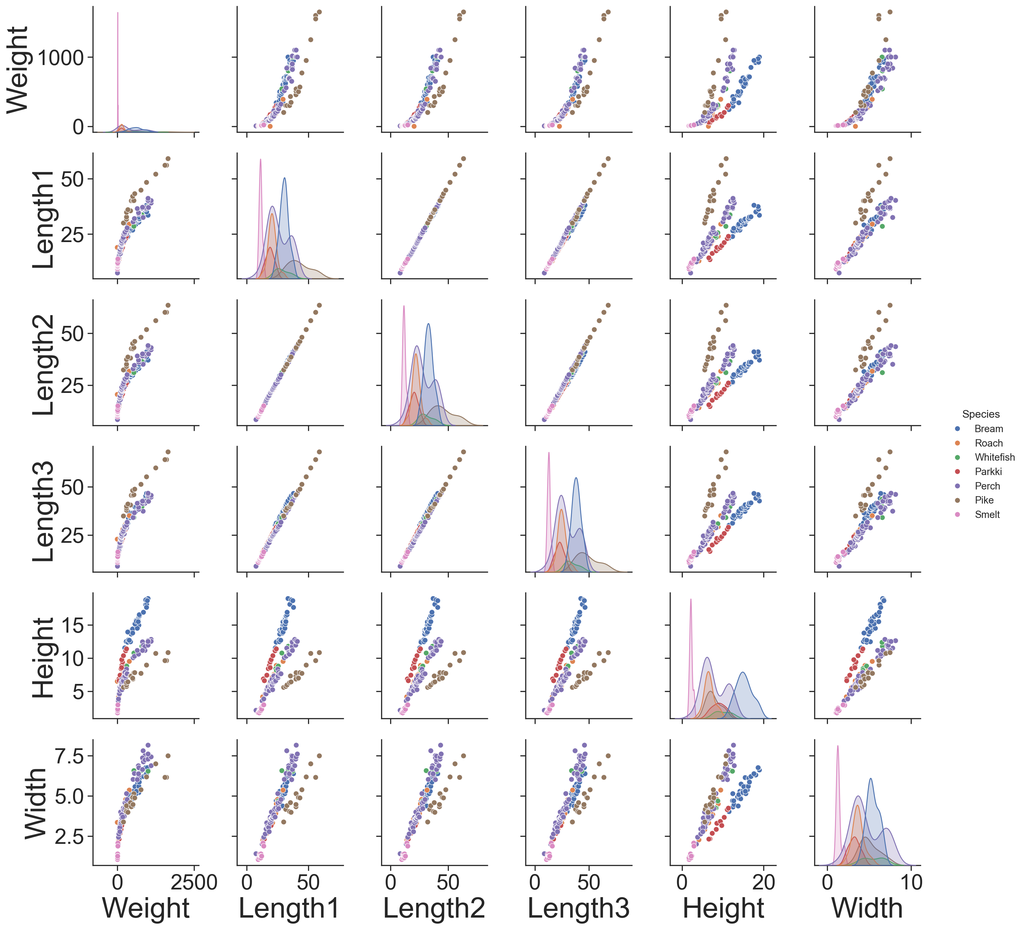

### Visualize the data

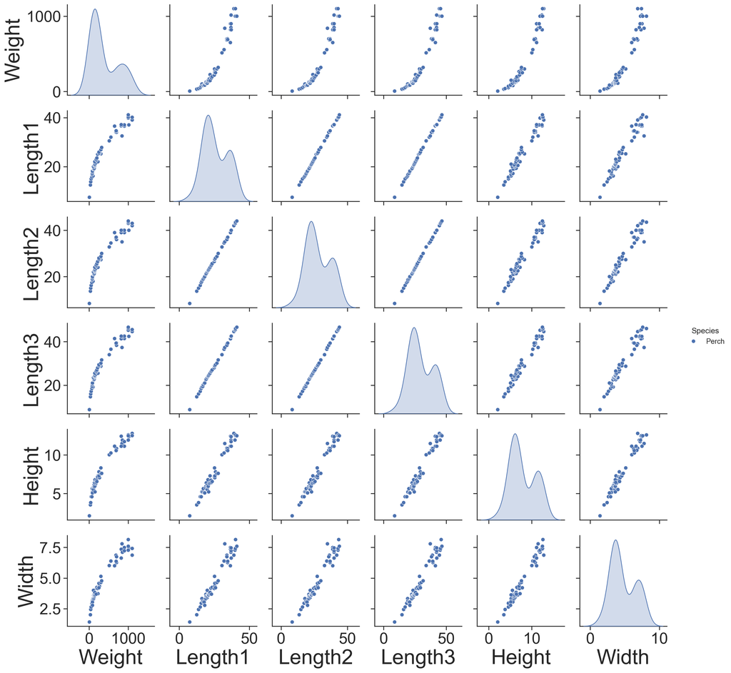

### Fitting a line with sklearn

```python
from sklearn.model_selection import train_test_split

train, test = train_test_split(df[df.Species=='Perch'], test_size=0.2)
```

Always pre-process your data so you have a training set and a test set! Otherwise you are liable to *over-fitting* your data.

### Normalization

Data can include very large and very small numbers - and this might differ column to column (eg house prices in dollars ($\sim$ millions) and areas in $\sim 10\text{s}$ of square metres). We want to normalize them to be of order unity, so that when we do maths with them our models will have appropriate normalisations straightforwardly:

```python
from sklearn import preprocessing

scaler = preprocessing.MinMaxScaler()
params = ['Weight','Length1','Length2','Length3','Height','Width']

scaler.fit(train[params])
train[params] = scaler.transform(train[params])
test[params] = scaler.transform(test[params])
train.head()
```

|  | Species | Weight | Length1 | Length2 | Length3 | Height | Width |
| --- | --- | --- | --- | --- | --- | --- | --- |
| 72 | Perch | 0.000000 | 0.000000 | 0.000000 | 0.000000 | 0.000000 | 0.000000 |
| 90 | Perch | 0.095147 | 0.372024 | 0.382022 | 0.388889 | 0.319090 | 0.384170 |
| 111 | Perch | 0.762362 | 0.744048 | 0.747191 | 0.753968 | 0.877267 | 0.948574 |
| 120 | Perch | 0.817201 | 0.877976 | 0.887640 | 0.891534 | 0.899871 | 0.863825 |
| 97 | Perch | 0.127136 | 0.431548 | 0.438202 | 0.441799 | 0.398851 | 0.358925 |

### Prediction in Data Science

Most questions you ever encounter will be of the form: given these data, can you *predict* new outputs given some metadata?

In the case where two things are *proportional*, this is easy:

```python
from sklearn.linear_model import LinearRegression

model = LinearRegression()
X_train, y_train = train[["Length1"]], train["Height"]
model.fit(X_train, y_train);
```

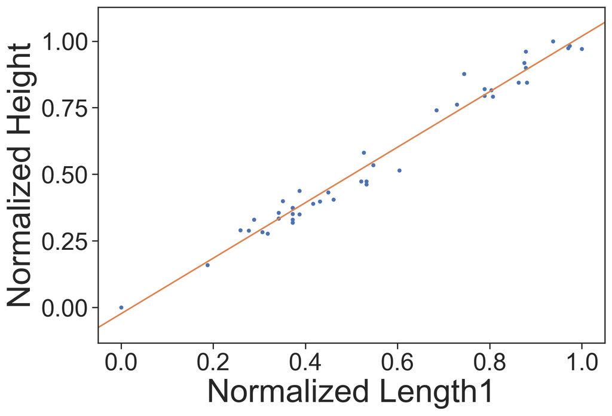

Linear Regression: The Maths

### Least Squares = Normal Statistics

- Suppose you have a *predictor* or *metadata* – an independent variables $x$ – which has very little uncertainty
- and you are trying to model a *dependent variable* $y$ which is noisy, as

$$y = mx + b + \epsilon$$

We want to *learn* $w$.

### Bayesian Inference: Conditional Probability

Fundamentally the problem of *inference* is about reasoning from data to the model that caused them. We can write Bayes’ theorem for conditional probability,

$$\color{teal}{p(\text{model}|\text{data})} = \frac{\color{gold}{p(\text{data}|\text{model})} \cdot \color{blue}{p(\text{model})}}{\color{gray}{p(\text{data})}}$$

- the prior is what we thought before,
- the likelihood is the conditional probabilty of getting the data,
- the evidence or “marginal likelihood” is a normalization constant that is hard to calculate, and
- the posterior is what we are trying to infer: our new belief about the model given the data.

### Linear Model: Inference

We want to be able to write down the likelihood of getting our data $Y$ given a model, so that if we start off with (say) a uniform prior on the other parameters we can reason to the best fitting parameters.

### Normal Likelihood

- Central limit theorem
  - *Frequentist View*: Realistic sources of error $\epsilon$ are normally distributed because they are sums of many processes.
  - *Bayesian View*: if you only know a point estimate and and uncertainty, the normal distribution is the Maximum Entropy distribution

So we can assume $\epsilon \sim \mathscr{N}(0, \sigma^2)$.

### Multivariate Normal

In general you can have *many* independent variables $x_1, x_2...$ that you collect into a matrix $X$ such that

$$y = \mathbf{X}\cdot \mathbf{w} + \epsilon$$

where

$$\mathbf{X} = \begin{bmatrix}
1 & x_{1,1} & x_{1,2} & ... \\
1 & x_{2,1} & x_{2,2} & ... \\
\vdots & \vdots & \vdots \\
1 & x_{n,1} & x_{n,2} & ...
\end{bmatrix}$$

$X$ is called a “design matrix”, and $w$ are coefficients.

The column of ones is there to allow us to have a constant term – an intercept $b$.

### Linear Algebra Solution

The simplest way to do this would be to invert the matrix $X$

$$\mathbf{w} = \mathbf{A}^{-1}\mathbf{Y}$$

but you can’t if there are more independent than dependent variables, because then the problem is over-constrained.

Instead we have an **ordinary least squares** solution

$$\mathbf{w} = (\mathbf{X}^T\mathbf{X})^{-1} \mathbf{X}^T \mathbf{y}$$

### Generalized Least Squares

To make this work with data with individual uncertainties we introduce the *covariance matrix* $C$ to represent the uncertainties $\sigma_i$ on each datapoint:

$$\mathbf{C} = \begin{bmatrix}
\sigma_1^2 & 0 & \cdots & 0 \\
0 & \sigma_2^2 & \cdots & 0 \\
\vdots & \vdots & \ddots & \vdots \\
0 & 0 & \cdots & \sigma_n^2
\end{bmatrix}$$

### Probability

It can be shown that this minimizes

$$\chi^2 \equiv \sum_{\forall i} \frac{(y_i - f(x_i))^2}{\sigma_i^2} = [\mathbf{Y}-\mathbf{X}\cdot\mathbf{w}]^T \mathbf{C}^{-1} [\mathbf{Y}-\mathbf{X}\mathbf{w}]$$

This is actually a Gaussian log-likelihood! For a multivariate normal distribution, the log likelihood is the quadratic form

$$p(x) \sim \mathscr{N}(\mu, \mathbf{C}) \rightarrow \log p(x) \propto (\mathbf{x}-\mu) \mathbf{C}^{-1} (\mathbf{x}-\mu)^T$$

which is what we have above! This is why we call it *least-squares* regression: it minimizes the sum of the square differences between data and model, normalized by the uncertainty on each datapoint.

### Implementation Under the Hood

Here’s how you would do what `sklearn` does from scratch in `numpy`:

```python
x = np.array(train["Length1"])
design_matrix = np.vander(x, 2) # this makes a matrix of polynomial terms
# in x from constant, linear, quadratic...
# we go up to linear!
print(design_matrix[:5])
y = train["Height"]

b, loss, rank, s  = np.linalg.lstsq(design_matrix, y)
# this does the whole expression in one go!

residuals = y - design_matrix @ b
```

```
[[0.         1.        ]
 [0.37202381 1.        ]
 [0.74404762 1.        ]
 [0.87797619 1.        ]
 [0.43154762 1.        ]]
```

### Linear doesn’t just mean lines!

The design matrix could be many things - terms of a polynomial, a Fourier series of sines and cosines, you name it.

We will do this in the SGTA!

### Uncertainty in the inference

It is just as important to know what the *uncertainty* on your inferred parameters are - we naturally get

$$\mathbf{C}_w \equiv \begin{bmatrix} \sigma_b^2 & \sigma_{mb} \\ \sigma_{mb} & \sigma_{m}^2 \end{bmatrix} = [\mathbf{X}^T \mathbf{C}_y^{-1} \mathbf{X}] ^{-1}$$

which means that if you want to quantify the uncertainty on your model you can draw samples from a multivariate normal to be your uncertain coefficients

### Uncertainty in the Inference

```python
uncertainty = np.std(residuals) * np.linalg.inv(design_matrix.T @ design_matrix)
for j in range(100):
    bb = stats.multivariate_normal.rvs(b, uncertainty)
    ...
```

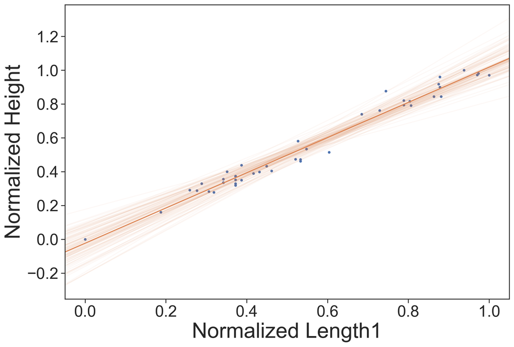

### Assessing Goodness-of-Fit

- **R-squared (Coefficient of Determination)**: Measures the proportion of the variance in the dependent variable that is predictable from the independent variables. Values range from 0 to 1, with higher values indicating a better fit.
- **Reduced Chi-Squared**: The chi-squared statistic divided by the degrees of freedom (number of observations minus number of fitted parameters). It indicates how well the model fits the data:
  - values $>> 1$ indicate the data are under-fit badly
  - values $\sim 1$ are good
  - values $<< 1$ indicate the data are over-fit
- **Root Mean Squared Error (RMSE)**: Lower values better - this is what we are fitting with least squares!
- **Median Absolute Error (MAE)**: median of absolute values of residuals. This is more robust to outliers.

### Anscombe’s Quartet

These datasets have all the same moments and trend line!

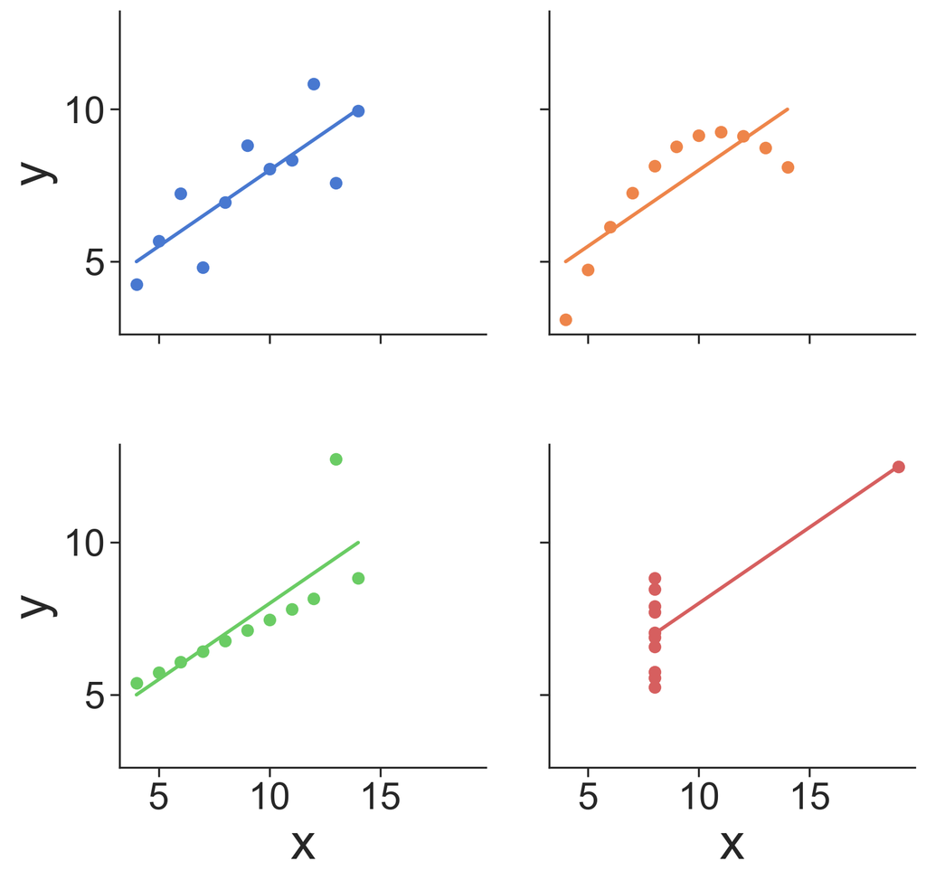

### Datasaurus Dozen

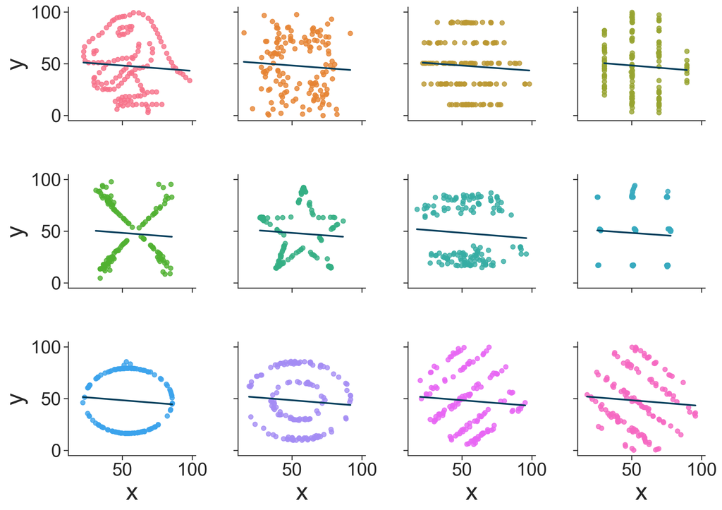

Categorical Data: Logistic Regression

### Coin Flips: the Bernoulli Distribution

The Bernoulli distribution is the simplest distribution of them all: you can use it to model coin flips or anything else with a binary outcome, like {dead,alive} or {asleep, awake}.

We write it as

$$x \sim \text{Bernoulli}(\theta)$$

### Regression over Categories

0 = awake, 1 = asleep.

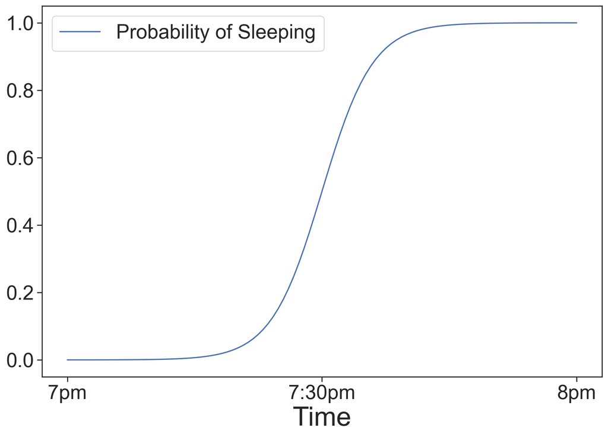

### Regression over Categories

0 = awake, 1 = asleep.

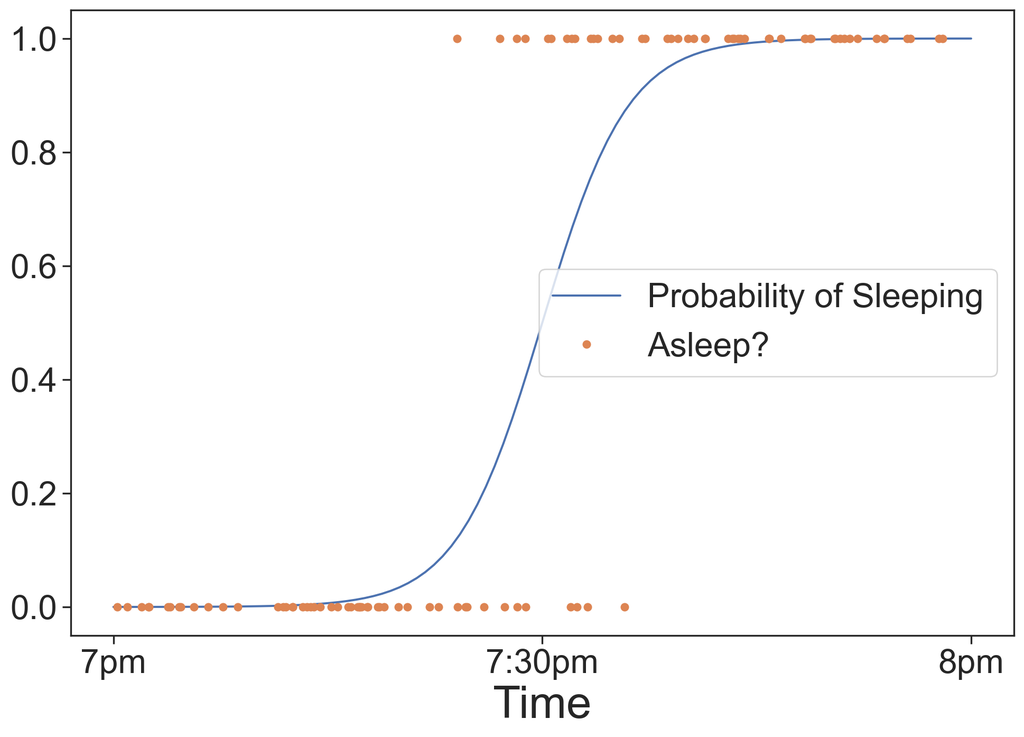

### Logistic Regression in sklearn

How would we *fit* something like this?

```python
from sklearn.linear_model import LogisticRegression
model = LogisticRegression()
model.C = 1e5 # inverse regularization parameter
X_train = x[:,np.newaxis]
y_train = y
model.fit(X_train, y_train);
```

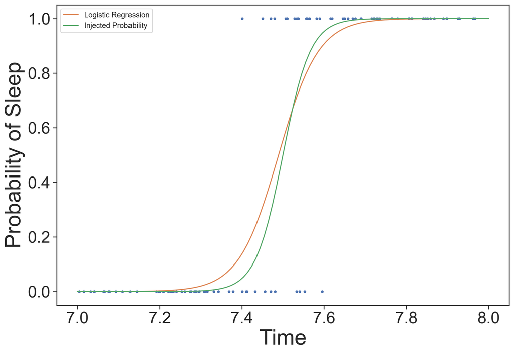

### Why “Logistic?”

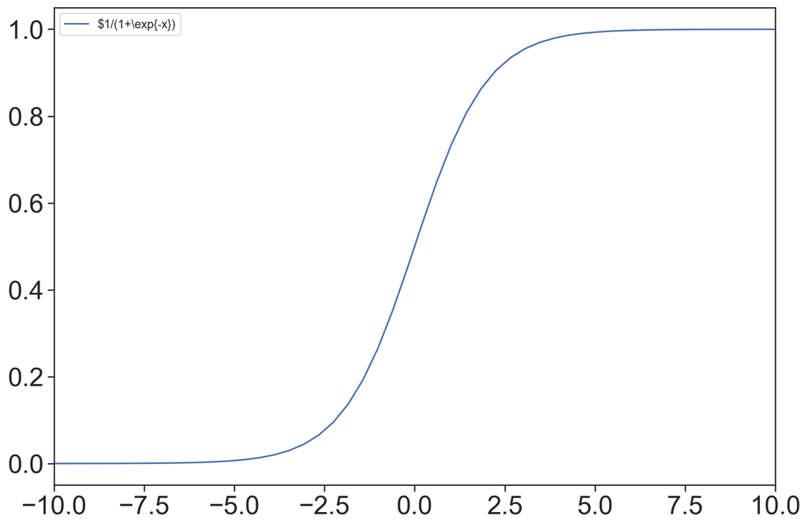

The logistic function $f(x) = \frac{1}{1+e^{-x}}$ satisfies the logistic equation $f'(x) = f(x)(1-f(x))$. Sometimes this is called a *sigmoid* because it looks like an S.

### Log odds to probability

We call the ratio of two probabilities $p(A)/p(B)$ the *odds ratio* $\mathscr{O}_{AB}$. If there are only two possibilities, then we have odds $p/(1-p)$.

The logistic function turns log-odds ratios back into probabilities:

$$\log{\frac{p}{1-p}} = r = \log{p} - \log{(1-p)}$$

so

$$\text{sig}(r) = \frac{1}{1 + \exp(-\log(p/(1-p)))}$$

$$= \frac{1}{1 + (1-p)/p}$$

which is just $p$.

(You can in fact pick any function that maps $(-\infty, \infty) \rightarrow (0,1)$, to wrap any function you like - there is no reason that this should just be linear except that it is simplest.)

### Logistic Regression: Under the Hood

We model our probabilities as a Bernoulli distribution, where the probability $\theta = \text{sig}(\mathbf{X}\cdot w)$ - ie a linear model fed through a sigmoid function to make it a probability from 0 to 1.

This has no closed form solution for $w$ but we can fit it numerically by *optimising* the parameters to minimize a *loss function* $\mathscr{L} = \sum_k \ell_k$ where

$$\ell_k = \begin{cases}
-\ln p_k & \text{ if } y_k = 1, \\
-\ln (1 - p_k) & \text{ if } y_k = 0.
\end{cases}$$

or

$$\ell_k = -y_k\ln p_k - (1 - y_k)\ln (1 - p_k)$$

which is called the *cross-entropy* of the predicted distribution from the actual distribution.

### Gradient Descent

Unlike with linear least squares, we can’t optimize this cost function analytically.

But we can solve it by *gradient descent*, by taking many small steps that make the loss function smaller.

In this case, we know the exact gradient analytically

$$\dfrac{\partial \mathscr{L}}{\partial w} \propto \mathbf{X} \cdot (\text{sig}(w^T \mathbf{X}) - \mathbf{Y})$$

so we can repeatedly evaluate the model, take a small step to improve the model, and evaluate it again.

In this case we have a really simple model and loss function, so with pen and paper we can calculate the gradients.

### What if we didn’t know the gradient?

If we had a more complicated model, we can still do this with **autodiff**: billions of dollars have been invested in packages like [PyTorch](https://pytorch.org/) and [Jax](https://docs.jax.dev/en/latest/index.html) which do all the same things as `numpy` but can also calculate gradients by the chain rule, for arbitrary functions.

Getting good at PyTorch (used more in production code) or Jax (used more in research) is essential to becoming a machine learning engineer or researcher - and *very* likely to improve your career!

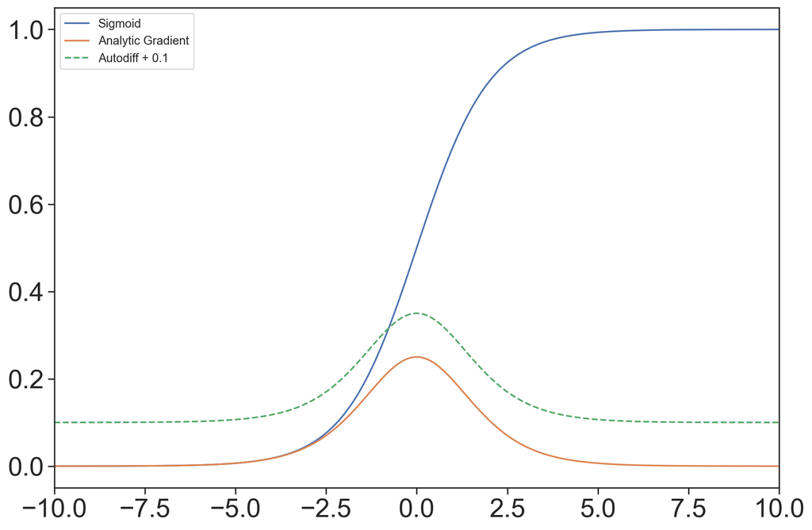

### This is AI

This is actually a single-layer neural network: we have *weights* $w$ applied to data $X$ as a *linear layer*, which we then pass through a nonlinear function - in this case a sigmoid function - which in AI we call an *activation*.

We *train* this by *gradient descent*.

A *neural network* is when you have a stack of linear layers and activations – there is a huge amount of science in how to stack them, and what the layers and activations should look like – trained by gradient descent with respect to data.

There is a remarkable theorem - these are *universal approximators*. Any function can be approximated to an arbitrary accuracy by an appropriately trained neural network!

You’re already learning AI!

Recap

### Today we have learned

- Linear regression
  - with `sklearn`
  - with pen and paper
  - with `numpy`
- Logistic regression
  - with `sklearn`
  - with gradient descent
  - what a neural network is!

[figure not shown]